# Lab 4

Austin Nebel

3/19/2021

```r
def <- read_excel('cyclonesFootball2020.xlsx', sheet='Defensive')
off <- read_excel('cyclonesFootball2020.xlsx', sheet='Offensive')
bio <- read_excel('cyclonesFootball2020.xlsx', sheet='Biography')
```

```r
head(def)
```

```
## # A tibble: 6 x 11
##   Name  Opponent_Oppone~ Tackles_Solo Tackles_ASST Tackles_TFL Tackles_Sack
##   <chr> <chr>            <chr>        <chr>        <chr>       <chr>
## 1 Rose~ Louisiana        2            4            1.0         0
## 2 Rose~ TCU              6            4            0           0
## 3 Rose~ Oklahoma         6            5            1.5         0.5
## 4 Rose~ Texas Tech       3            0            1.0         0
## 5 Rose~ Oklahoma St.     7            3            1.0         0
## 6 Rose~ Kansas           4            1            0           0
## # ... with 5 more variables: Turnover_FF <chr>, Turnover_FR <chr>,
## #   Turnover_INT <chr>, Pass_QBH <chr>, Pass_PB <chr>
```

```r
head(off)
```

```
## # A tibble: 6 x 12
##   Name  Opponent_Oppone~ Receiving_REC Receiving_YDS Receiving_TD Rushing_ATT
##   <chr> <chr>            <chr>         <chr>         <chr>        <chr>
## 1 Aker~ Louisiana        0             0             0            <NA>
## 2 Aker~ TCU              2             60            0            <NA>
## 3 Aker~ Oklahoma         1             35            0            <NA>
## 4 Aker~ Texas Tech       4             34            0            <NA>
## 5 Aker~ Oklahoma St.     0             0             0            <NA>
## 6 Aker~ Kansas           6             76            0            <NA>
## # ... with 6 more variables: Rushing_YDS <chr>, Rushing_TD <chr>,
## #   `Passing_CMP-ATT` <chr>, Passing_YDS <chr>, Passing_TD <chr>,
## #   Passing_INT <chr>
```

```r
head(bio)
```

```
## # A tibble: 6 x 7
##   Name          Position    Height Weight Class       Hometown      Highschool
##   <chr>         <chr>       <chr>  <chr>  <chr>       <chr>         <chr>
## 1 Akers, Landen Wide Recei~ 6-0    191    Redshirt S~ Cedar Rapids~ Washington
## 2 Allen, Chase  Tight End   6-7    240    Redshirt S~ Nixa, Mo.     Nixa
## 3 Anderson, Ez~ Wide Recei~ 6-5    208    Redshirt F~ Seffner, Fla. Armwood
## 4 Antoine Jr. ~ Defensive ~ 6-0    180    Freshman    Ft. Lauderda~ Cardinal Gi~
## 5 Assalley, Co~ Placekicker 6-0    195    Redshirt S~ Naperville, ~ Central
## 6 Azunna, Arno~ Defensive ~ 6-0    199    Redshirt S~ Grand Prairi~ Lake Ridge
```

## Part one: Cleaning data

Although the three Excel sheets are loaded into R, they are not useful before some cleaning. Manipulate the three imported data frames, so that in the cleaned dataset:

1. The player names and opponent names are factors.
2. All offensive and defensive statistics are numerical. The Weight column in biography is also numeric. (Optional: Read ?across and learn to mutate multiple columns simultaneously using the across function in dplyr)
3. Change the Height column in biography into numeric. (Hint: Use a unit that works well)

By cleaning the three data frames in R, at the end of this step you should have the following three clean data frames: defClean, offClean, and bioClean. Print the structures of these data frames using str().

```r
def$Name <- as.factor(def$Name)
def$Opponent_Opponent <- as.factor(def$Opponent_Opponent)

off$Name <- as.factor(off$Name)
off$Opponent_Opponent <- as.factor(off$Opponent_Opponent)
```

```r
defClean <- def %>%
  mutate(across(3:11, as.numeric))

off$`Passing_CMP-ATT` <- as.integer(gsub('-', '', off$`Passing_CMP-ATT`)) #removes `-` symbol from this column to prevent NA's
offClean <- off %>%
  mutate(across(3:12, as.numeric))


bioClean <- bio %>%
  separate(Height, c("Feet", "Inches")) %>% #split height by '-' into ft and inch
  mutate(across(c("Feet", "Inches"), as.numeric)) %>% #make feet in inch numeric
  mutate(Inches = Inches/12 ) %>% #make inches a percentage out of 12
  mutate(Height = round(Feet + Inches,2)) %>% #Add feet and inches into new height column and round
  select(-c("Feet", "Inches")) %>% #remove ft and inch columns
  mutate(across("Weight", as.numeric)) #make weight numeric


str(defClean)
```

```
## tibble [372 x 11] (S3: tbl_df/tbl/data.frame)
##  $ Name             : Factor w/ 37 levels "Akers, Landen",..: 26 26 26 26 26 26 26 26 26 26 ...
##  $ Opponent_Opponent: Factor w/ 11 levels "Baylor","Kansas",..: 4 8 5 10 6 2 1 3 9 11 ...
##  $ Tackles_Solo     : num [1:372] 2 6 6 3 7 4 7 4 4 2 ...
##  $ Tackles_ASST     : num [1:372] 4 4 5 0 3 1 4 3 9 3 ...
##  $ Tackles_TFL      : num [1:372] 1 0 1.5 1 1 0 1.5 2.5 1.5 0 ...
##  $ Tackles_Sack     : num [1:372] 0 0 0.5 0 0 0 0 1 0 0 ...
##  $ Turnover_FF      : num [1:372] 0 0 0 0 0 0 0 0 0 0 ...
##  $ Turnover_FR      : num [1:372] 0 0 0 0 0 0 0 0 0 0 ...
##  $ Turnover_INT     : num [1:372] 0 1 0 0 1 0 1 1 0 0 ...
##  $ Pass_QBH         : num [1:372] 0 0 1 0 0 0 2 1 0 0 ...
##  $ Pass_PB          : num [1:372] 0 0 0 0 0 1 0 0 1 0 ...
```

```r
str(offClean)
```

```
## tibble [156 x 12] (S3: tbl_df/tbl/data.frame)
##  $ Name             : Factor w/ 16 levels "Akers, Landen",..: 1 1 1 1 1 1 1 1 1 1 ...
##  $ Opponent_Opponent: Factor w/ 11 levels "Baylor","Kansas",..: 4 8 5 10 6 2 1 3 9 11 ...
##  $ Receiving_REC    : num [1:156] 0 2 1 4 0 6 1 0 1 1 ...
##  $ Receiving_YDS    : num [1:156] 0 60 35 34 0 76 11 0 10 2 ...
##  $ Receiving_TD     : num [1:156] 0 0 0 0 0 0 0 0 0 1 ...
##  $ Rushing_ATT      : num [1:156] NA NA NA NA NA NA NA NA NA NA ...
##  $ Rushing_YDS      : num [1:156] NA NA NA NA NA NA NA NA NA NA ...
##  $ Rushing_TD       : num [1:156] NA NA NA NA NA NA NA NA NA NA ...
##  $ Passing_CMP-ATT  : num [1:156] NA NA NA NA NA NA NA NA NA NA ...
##  $ Passing_YDS      : num [1:156] NA NA NA NA NA NA NA NA NA NA ...
##  $ Passing_TD       : num [1:156] NA NA NA NA NA NA NA NA NA NA ...
##  $ Passing_INT      : num [1:156] NA NA NA NA NA NA NA NA NA NA ...
```

```r
str(bioClean)
```

```
## tibble [116 x 7] (S3: tbl_df/tbl/data.frame)
##  $ Name      : chr [1:116] "Akers, Landen" "Allen, Chase" "Anderson, Ezeriah" "Antoine Jr. , Michal" ...
##  $ Position  : chr [1:116] "Wide Receiver" "Tight End" "Wide Receiver" "Defensive Back" ...
##  $ Weight    : num [1:116] 191 240 208 180 195 199 253 261 288 182 ...
##  $ Class     : chr [1:116] "Redshirt Senior" "Redshirt Senior" "Redshirt Freshman" "Freshman" ...
##  $ Hometown  : chr [1:116] "Cedar Rapids, Iowa" "Nixa, Mo." "Seffner, Fla." "Ft. Lauderdale, Fla." ...
##  $ Highschool: chr [1:116] "Washington" "Nixa" "Armwood" "Cardinal Gibbons" ...
##  $ Height    : num [1:116] 6 6.58 6.42 6 6 6 6.25 6.17 6.17 6.17 ...
```

## Part two: Tidying

For the following questions, work on the cleaned data frames defClean, offClean, and bioClean.

1. Reformat the offClean data frame into a tidy format using pivot_longer. The type of statistic (Receiving_REC for the number of receivings, Receiving_YDS for receiving yards, etc) is added as a new key column named stat.
2. Show on the distributions of the offensive statistics. The distribution of each offensive statsitic should be shown in a separate facet. Explain the patterns you see.
3. Did ISU have better offense against Oregon or Oklahoma? Answer this question by creating a scatterplot with the x- and y-axes being the receiving yards of the ISU players against these two opponents. A large number of receiving yards indicates good offense.

Now turn our attention to the player biography.

4. Separate the Hometown column into two columns, namely, the city and the state where the player comes from. Print the first few rows of these two columns. (Hint: look at the sep= argument of separate)
5. How many players are there from each state?

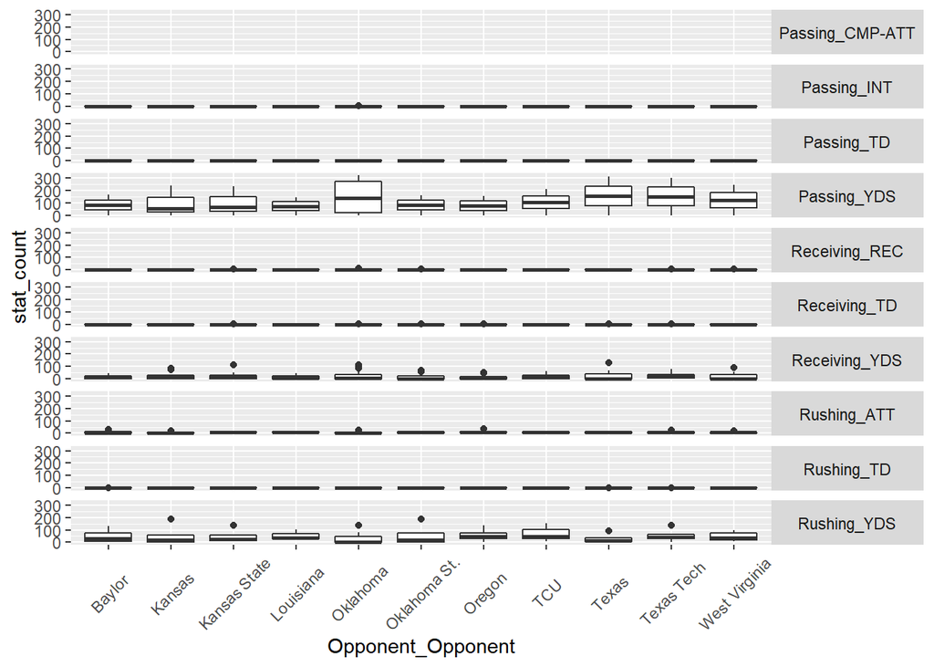

```r
offClean <- offClean %>%
  pivot_longer(3:12, names_to = "stat", values_to = "stat_count")

offClean %>%
  ggplot(aes(x=Opponent_Opponent, y=stat_count)) + geom_boxplot() + facet_grid(rows="stat")+
  theme(strip.text.y.right = element_text(angle = 0), axis.text.x = element_text(angle = 45, vjust = 0.5))
```

ISU has a wider range of passing years than most other statistics. Their rushing yards are much less thatn their passing yards.

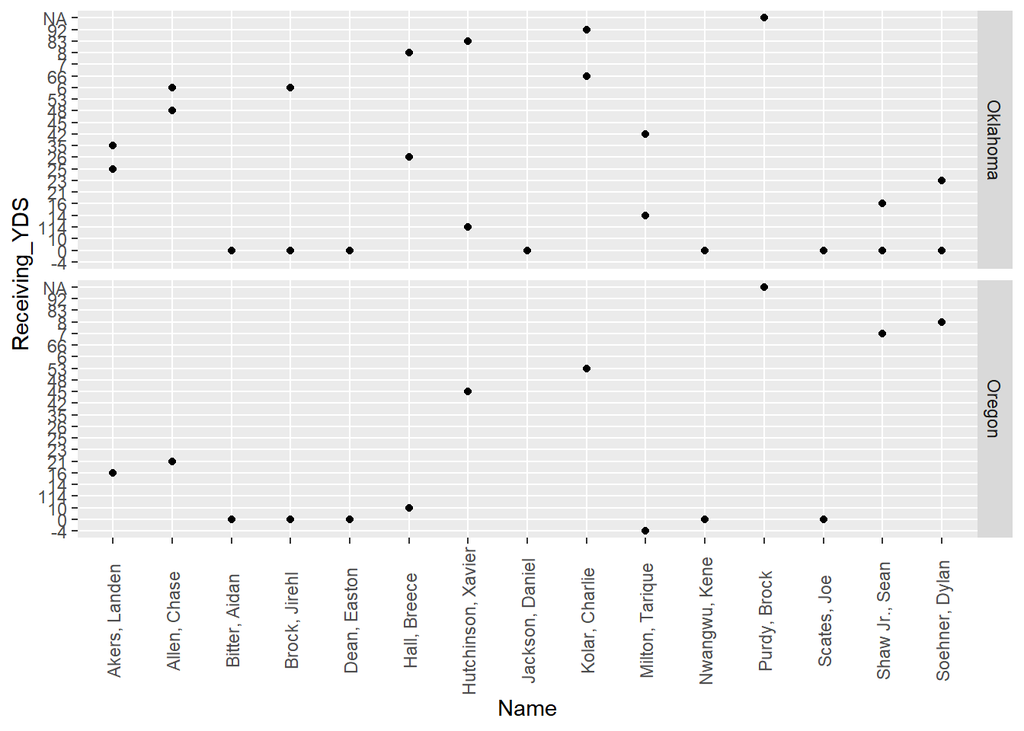

```r
off %>%
  filter(Opponent_Opponent == "Oregon" | Opponent_Opponent == "Oklahoma") %>%
  ggplot(aes(x=Name, y=Receiving_YDS)) + geom_point()  + facet_grid(rows="Opponent_Opponent") +
  theme(axis.text.x = element_text(angle = 90, vjust=0.5))
```

ISU had a better game against Oklahoma. This can be seen in both this facet plot and the previous one.

```r
bioSep <- bioClean %>%
  separate(Hometown, c("City", "State"), sep=", ")

head(bioSep)
```

```
## # A tibble: 6 x 8
##   Name         Position    Weight Class       City     State Highschool   Height
##   <chr>        <chr>        <dbl> <chr>       <chr>    <chr> <chr>         <dbl>
## 1 Akers, Land~ Wide Recei~    191 Redshirt S~ Cedar R~ Iowa  Washington     6
## 2 Allen, Chase Tight End      240 Redshirt S~ Nixa     Mo.   Nixa           6.58
## 3 Anderson, E~ Wide Recei~    208 Redshirt F~ Seffner  Fla.  Armwood        6.42
## 4 Antoine Jr.~ Defensive ~    180 Freshman    Ft. Lau~ Fla.  Cardinal Gi~   6
## 5 Assalley, C~ Placekicker    195 Redshirt S~ Napervi~ Ill.  Central        6
## 6 Azunna, Arn~ Defensive ~    199 Redshirt S~ Grand P~ Texas Lake Ridge     6
```

```r
bioSep %>% group_by(State) %>%
  summarise(`State_Count` = n())
```

```
## # A tibble: 21 x 2
##    State     State_Count
##  * <chr>           <int>
##  1 Ariz.               4
##  2 Ark.                1
##  3 Australia           1
##  4 Calif.              2
##  5 Fla.               14
##  6 Ga.                 3
##  7 Ill.                6
##  8 Iowa               42
##  9 Kan.                4
## 10 Mich                1
## # ... with 11 more rows
```

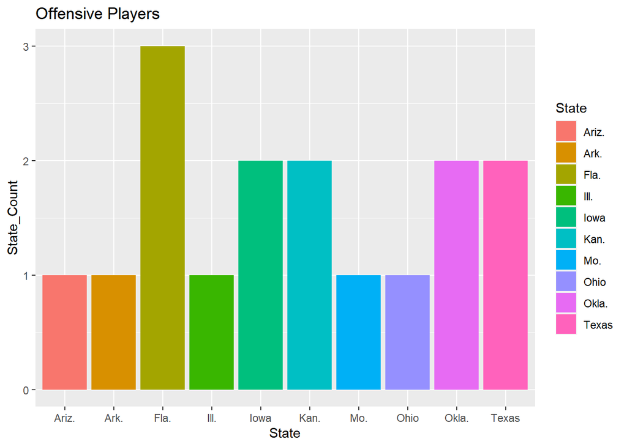

```r
select(bioSep, Name, State) %>%
  semi_join(offClean, by=c("Name" = "Name")) %>%
  group_by(State) %>%
  summarise(`State_Count` = n()) %>%
  ggplot(aes(x=State, y=`State_Count`, fill=State)) + geom_bar(stat="identity") + ggtitle("Offensive Players")
```

[figure not shown]

```r
select(bioSep, Name, State) %>%
  semi_join(defClean, by=c("Name" = "Name"))%>% group_by(State) %>%
  summarise(`State_Count` = n()) %>%
  ggplot(aes(x=State, y=`State_Count`, fill=State)) + geom_bar(stat="identity") + ggtitle("Offensive Players")
```

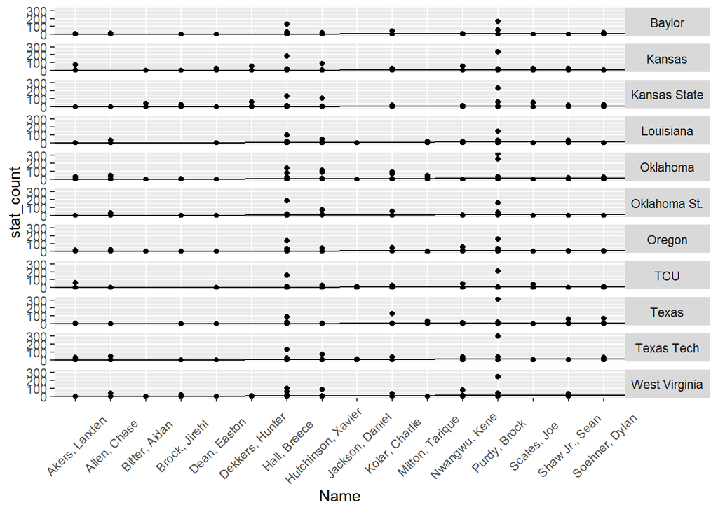

```r
offClean %>%
  select(Name, stat_count, Opponent_Opponent) %>%
  ggplot(aes(x=Name, y=stat_count)) + geom_point()  + facet_grid(rows="Opponent_Opponent") + geom_abline() +
  theme(strip.text.y.right = element_text(angle = 0), axis.text.x = element_text(angle = 45, vjust = 0.5))
```